# Lab12

Hoa Hoang

Friday, April 17, 2020

## Task 1

```r
getwd()
```

```
## [1] "C:/Users/hoaho/OneDrive/Desktop/Classworks/Math4753/Lab12"
```

## Task 2

### Create the sample x1

```r
set.seed(55);x1=rnorm(30,mean=25,sd=5)
```

### t.test()

```r
#mu=22
t.test(x1,mu=22)
```

```
##
##  One Sample t-test
##
## data:  x1
## t = 3.3863, df = 29, p-value = 0.002052
## alternative hypothesis: true mean is not equal to 22
## 95 percent confidence interval:
##  23.30198 27.27320
## sample estimates:
## mean of x
##  25.28759
```

```r
#mu=23
t.test(x1,mu=23)
```

```
##
##  One Sample t-test
##
## data:  x1
## t = 2.3563, df = 29, p-value = 0.02543
## alternative hypothesis: true mean is not equal to 23
## 95 percent confidence interval:
##  23.30198 27.27320
## sample estimates:
## mean of x
##  25.28759
```

```r
#mu=24
t.test(x1,mu=24)
```

```
##
##  One Sample t-test
##
## data:  x1
## t = 1.3263, df = 29, p-value = 0.1951
## alternative hypothesis: true mean is not equal to 24
## 95 percent confidence interval:
##  23.30198 27.27320
## sample estimates:
## mean of x
##  25.28759
```

```r
#mu=25
t.test(x1,mu=25)
```

```
##
##  One Sample t-test
##
## data:  x1
## t = 0.29623, df = 29, p-value = 0.7692
## alternative hypothesis: true mean is not equal to 25
## 95 percent confidence interval:
##  23.30198 27.27320
## sample estimates:
## mean of x
##  25.28759
```

```r
#mu=26
t.test(x1,mu=26)
```

```
##
##  One Sample t-test
##
## data:  x1
## t = -0.7338, df = 29, p-value = 0.469
## alternative hypothesis: true mean is not equal to 26
## 95 percent confidence interval:
##  23.30198 27.27320
## sample estimates:
## mean of x
##  25.28759
```

95 percent confidence interval: 23.30198 27.27320  
Reject $H_0:\mu=22$ and $H_0:\mu=23$ since thier p are less than 0.05  
Accept all the rest

### Boxplot

```r
boxplot(x1, main="Sample x1")
xbar=mean(x1)
ci=t.test(x1,mu=xbar)$conf.int
ci
```

```
## [1] 23.30198 27.27320
## attr(,"conf.level")
## [1] 0.95
```

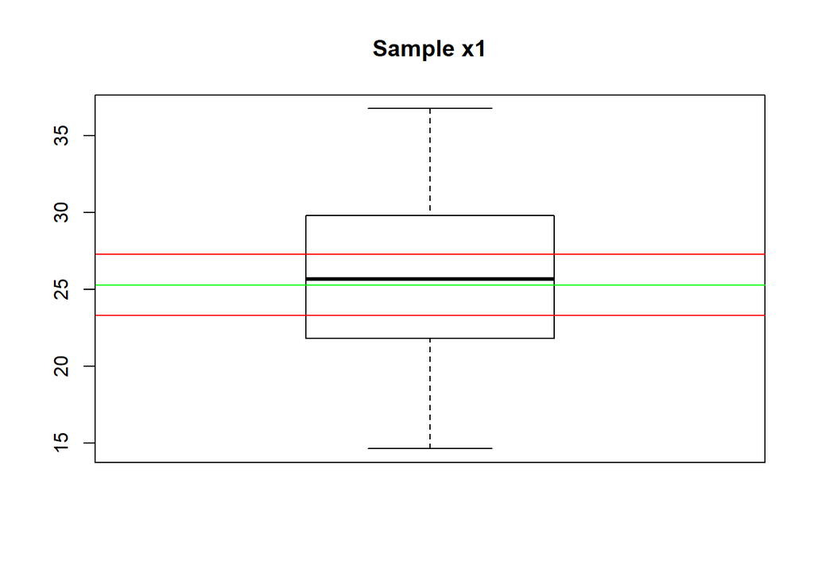

```r
abline(h=c(ci,mean(x1)),col=c("Red","Red","Green"))
```

### Pivotal t_calc with null hypothesis, mu = 24

```r
t_calc = (xbar-24)/(sd(x1)/sqrt(length(x1)))
t_calc
```

```
## [1] 1.326252
```

### mypvalue()

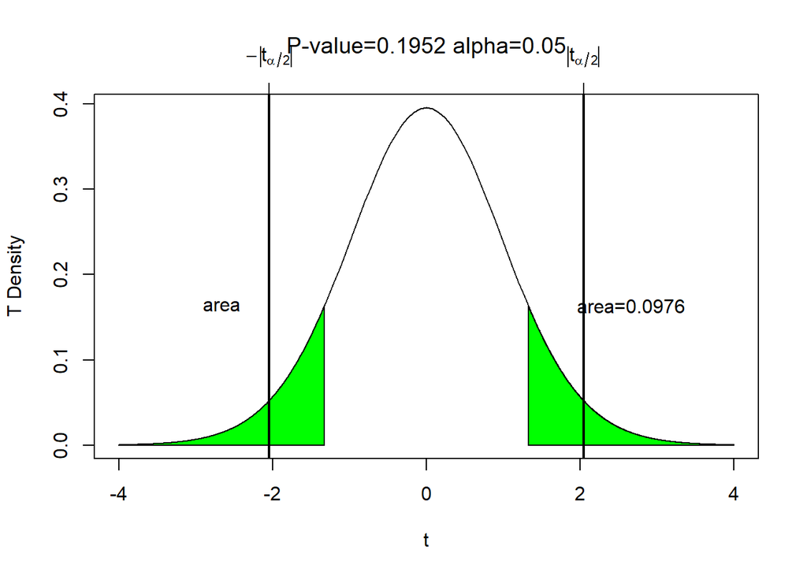

```
## $q
## [1] 2.04523
##
## $pvalue
## [1] 0.1952
```

```r
#### FUNCTION for Pvalues
# Display P-value areas
mypvalue=function(t0,xmax=4,n=20, alpha=0.05){
#calculate alpha/2
va=round(pt(-t0,df=n-1),4)
pv=2*va

# plot the t dist
curve(dt(x,df=n-1),xlim=c(-xmax,xmax),ylab="T Density",xlab=expression(t),
main=substitute(paste("P-value=", pv, " alpha=", alpha)))


# set up points on the polygon to the right
xcurve=seq(t0,xmax,length=1000)
ycurve=dt(xcurve,df=n-1)

# set up points to the left
xlcurve=seq(-t0,-xmax,length=1000)
ylcurve=dt(xcurve,df=n-1)

# Shade in the polygon defined by the line segments
polygon(c(t0,xcurve,xmax),c(0,ycurve,0),col="green")
polygon(c(-t0,xlcurve,-xmax),c(0,ylcurve,0),col="green")

# make quantiles
q=qt(1-alpha/2,n-1)
abline( v=c(q,-q),lwd=2) # plot the cut off t value
axis(3,c(q,-q),c(expression(abs(t[alpha/2])),expression(-abs(t[alpha/2]))))


# Annotation
text(0.5*(t0+xmax),max(ycurve),substitute(paste(area, "=",va)))
text(-0.5*(t0+xmax),max(ycurve),expression(area))

return(list(q=q,pvalue=pv))
}
##### END of FUNCTION for P VALUES    #####

mypvalue(t0=t_calc,n=30,alpha=0.05)
```

### bootstrap p-values

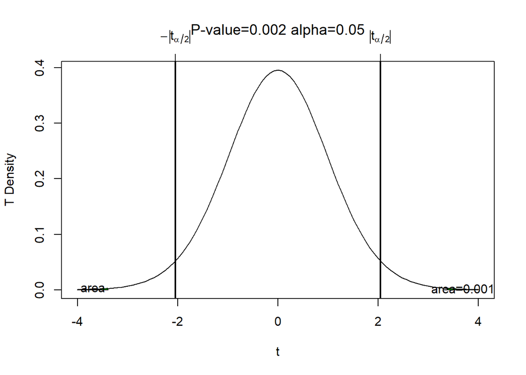

```
## $q
## [1] 2.04523
##
## $pvalue
## [1] 0.002
```

```r
#mu=22
t_calc = (xbar-22)/(sd(x1)/sqrt(length(x1)))
mypvalue(t0=t_calc,n=30,alpha=0.05)
```

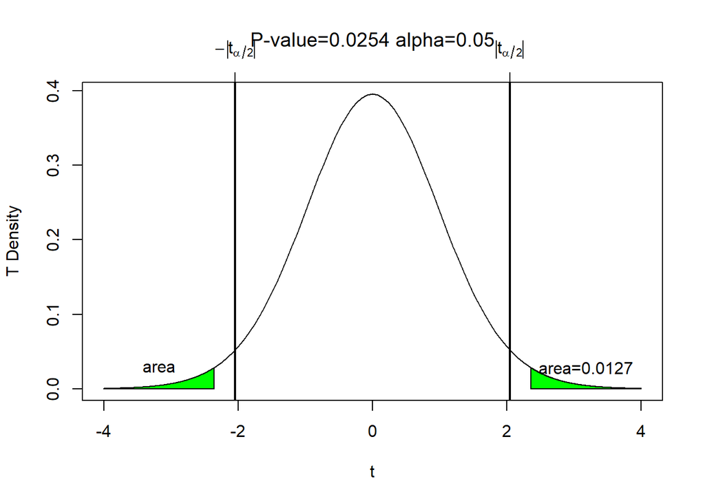

```
## $q
## [1] 2.04523
##
## $pvalue
## [1] 0.0254
```

```r
#mu=23
t_calc = (xbar-23)/(sd(x1)/sqrt(length(x1)))
mypvalue(t0=t_calc,n=30,alpha=0.05)
```

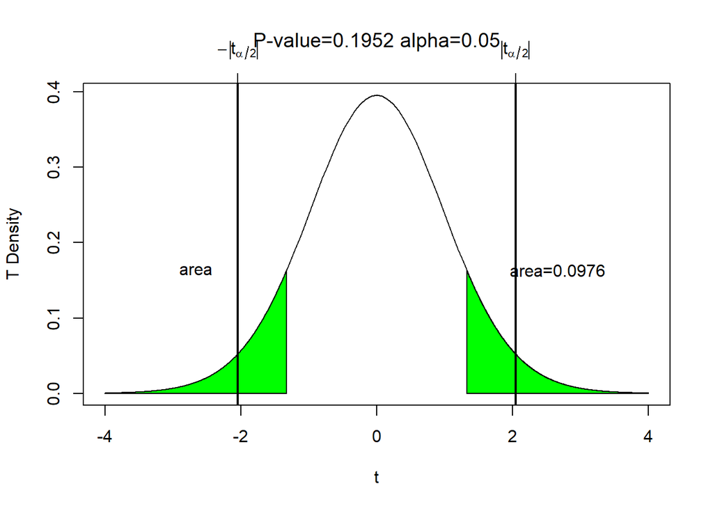

```
## $q
## [1] 2.04523
##
## $pvalue
## [1] 0.1952
```

```r
#mu=24
t_calc = (xbar-24)/(sd(x1)/sqrt(length(x1)))
mypvalue(t0=t_calc,n=30,alpha=0.05)
```

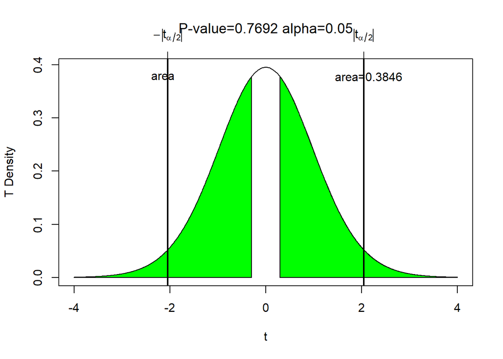

```
## $q
## [1] 2.04523
##
## $pvalue
## [1] 0.7692
```

```r
#mu=25
t_calc = (xbar-25)/(sd(x1)/sqrt(length(x1)))
mypvalue(t0=t_calc,n=30,alpha=0.05)
```

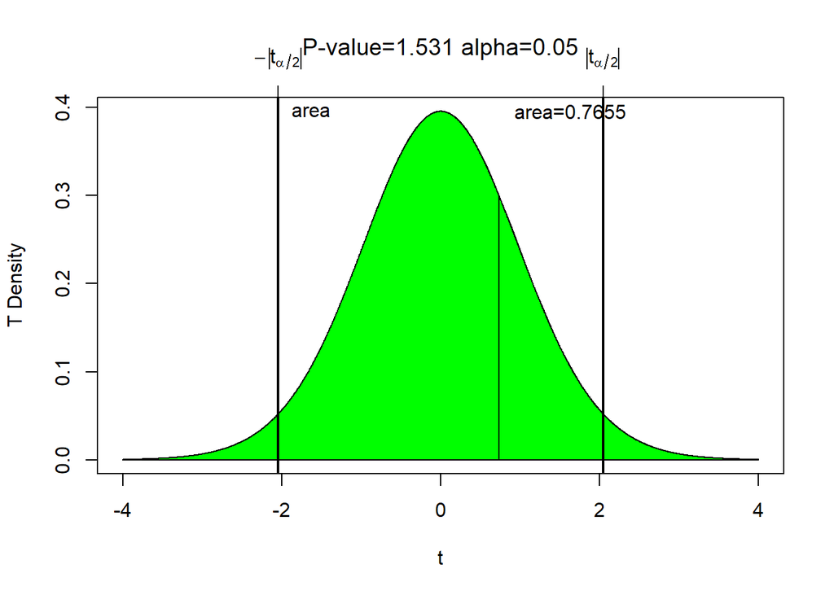

```
## $q
## [1] 2.04523
##
## $pvalue
## [1] 1.531
```

```r
#mu=26
t_calc = (xbar-26)/(sd(x1)/sqrt(length(x1)))
mypvalue(t0=t_calc,n=30,alpha=0.05)
```

As we can see, P values are more than 0.05 for all the accepted

## Task 3

### var.test()

```r
set.seed(30);x=rnorm(15,mean=10,sd=7)
set.seed(40);y=rnorm(20,mean=12,sd=4)
var.test(x,y)
```

```
##
##  F test to compare two variances
##
## data:  x and y
## F = 3.3363, num df = 14, denom df = 19, p-value = 0.01596
## alternative hypothesis: true ratio of variances is not equal to 1
## 95 percent confidence interval:
##  1.260446 9.544255
## sample estimates:
## ratio of variances
##            3.33631
```

p-value = 0.01596. We reject the null hyphothesis. The var are not equal

### t.test()

$H_0:\mu_y-\mu_x=0$, $H_1:\mu_y-\mu_x \neq 0$

```r
t.test(y,x,mu=0,var.equal = F)
```

```
##
##  Welch Two Sample t-test
##
## data:  y and x
## t = 1.7945, df = 20.248, p-value = 0.08768
## alternative hypothesis: true difference in means is not equal to 0
## 95 percent confidence interval:
##  -0.5950525  7.9632156
## sample estimates:
## mean of x mean of y
## 11.674425  7.990343
```

$H_0:\mu_y-\mu_x=2$, $H_1:\mu_y-\mu_x \neq 2$

```r
t.test(y,x,mu=2,var.equal = F)
```

```
##
##  Welch Two Sample t-test
##
## data:  y and x
## t = 0.8203, df = 20.248, p-value = 0.4216
## alternative hypothesis: true difference in means is not equal to 2
## 95 percent confidence interval:
##  -0.5950525  7.9632156
## sample estimates:
## mean of x mean of y
## 11.674425  7.990343
```

The closer p value to one, the more accrute our hypothesis is It is more likely that the mean is different by 2

## Task 4

### var.test()

```r
set.seed(30);x=rnorm(15,mean=10,sd=4)
set.seed(40);y=rnorm(20,mean=12,sd=4)
var.test(x,y)
```

```
##
##  F test to compare two variances
##
## data:  x and y
## F = 1.0894, num df = 14, denom df = 19, p-value = 0.8454
## alternative hypothesis: true ratio of variances is not equal to 1
## 95 percent confidence interval:
##  0.4115743 3.1164915
## sample estimates:
## ratio of variances
##           1.089407
```

p-value = 0.8454. We go with the null hyphothesis. The var are equal

### t.test()

$H_0:\mu_y-\mu_x=0$, $H_1:\mu_y-\mu_x \neq 0$

```r
t.test(y,x,mu=0,var.equal = T)
```

```
##
##  Two Sample t-test
##
## data:  y and x
## t = 2.0623, df = 33, p-value = 0.04712
## alternative hypothesis: true difference in means is not equal to 0
## 95 percent confidence interval:
##  0.03803598 5.60756393
## sample estimates:
## mean of x mean of y
## 11.674425  8.851625
```

$H_0:\mu_y-\mu_x=2$, $H_1:\mu_y-\mu_x \neq 2$

```r
t.test(y,x,mu=2,var.equal = T)
```

```
##
##  Two Sample t-test
##
## data:  y and x
## t = 0.60113, df = 33, p-value = 0.5519
## alternative hypothesis: true difference in means is not equal to 2
## 95 percent confidence interval:
##  0.03803598 5.60756393
## sample estimates:
## mean of x mean of y
## 11.674425  8.851625
```

It is more likely that the mean is different by 2

## Task 5

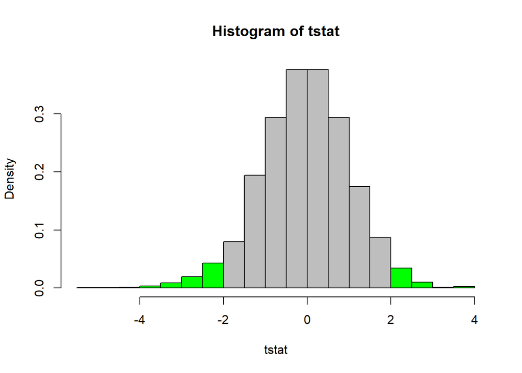

```
## $pvalue
## [1] 0.08666667
```

```r
## Bootstrap interval for a two sample test
boot2pval<-function(x1,x2,conf.level=0.95,iter=3000,mudiff=0, test="two"){
n1=length(x1)
n2=length(x2)
y1=x1-mean(x1)+mean(c(x1,x2))  # transform the data so that it is centered at the NULL
y2=x2-mean(x2)+mean(c(x1,x2))
y1rs.mat<-c()    #rs.mat will be come a resample matrix -- now it is an empty vector
x1rs.mat<-c()
y2rs.mat<-c()
x2rs.mat<-c()
for(i in 1:iter){ # for loop - the loop will go around iter times
y1rs.mat<-cbind(y1rs.mat,sample(y1,n1,replace=TRUE)) #sampling from y cbind -- column bind -- binds the vectors together by columns
y2rs.mat<-cbind(y2rs.mat,sample(y2,n2,replace=TRUE))

}
x1rs.mat<-y1rs.mat+mean(x1)-mean(c(x1,x2))
x2rs.mat<-y2rs.mat+mean(x2)-mean(c(x1,x2))

xbar1=mean(x1)
xbar2=mean(x2)
sx1sq=var(x1)
sx2sq=var(x2)

tcalc=(xbar1-xbar2-mudiff)/sqrt(sx1sq/n1+sx2sq/n2)

sy1sq=apply(y1rs.mat,2,var)
sy2sq=apply(y2rs.mat,2,var)
y1bar=apply(y1rs.mat,2,mean)
y2bar=apply(y2rs.mat,2,mean)

tstat=(y1bar-y2bar-mudiff)/sqrt(sy1sq/n1+sy2sq/n2)


alpha=1-conf.level # calculating alpha
#ci=quantile(xstat,c(alpha/2,1-alpha/2))# Nice way to form a confidence interval
pvalue=ifelse(test=="two",length(tstat[tstat>abs(tcalc) | tstat < -abs(tcalc)])/iter,
ifelse(test=="upper",length(tstat[tstat>tcalc])/iter,
length(ytstat[tstat<tcalc])/iter))

h=hist(tstat,plot=FALSE)
mid=h$mid
if(test=="two"){
ncoll=length(mid[mid<= -abs(tcalc)])
ncolr=length(mid[mid>=  abs(tcalc)])
col=c(rep("Green",ncoll),rep("Gray",length(mid)-ncoll-ncolr),rep("Green",ncolr))
}
hist(tstat,col=col,freq=FALSE)
#segments(ci[1],0,ci[2],0,lwd=2)

return(list(pvalue=pvalue))
#return(list(pvalue=pvalue,tcalc=tcalc,n=n,x=x,test=test,ci=ci))
}
set.seed(30);x=rnorm(15,mean=10,sd=7)
set.seed(40);y=rnorm(20,mean=12,sd=4)
boot2pval(x1=x,x2=y)
```

## Task 6

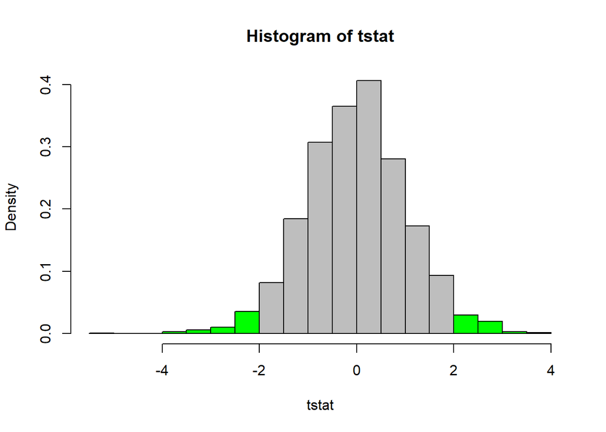

```
## $pvalue
## [1] 0.04833333
```

```r
set.seed(30);x=rnorm(15,mean=10,sd=4)
set.seed(40);y=rnorm(20,mean=12,sd=4)
boot2pval(x1=x,x2=y)
```

## Task 7

Line A is perform t.test on x1 with $H_0:\mu=23$  
Line B is indicate that this is a one sample t-test  
Line C give the value of t, p, and degree of freedom  
Line D state that the alternative hypothesis: $H_1:\mu \neq 23$  
Line E is just the description of CI, default if 95%  
Line F is the 95% CI  
Line G is the estimate mean of x1

## Task 8

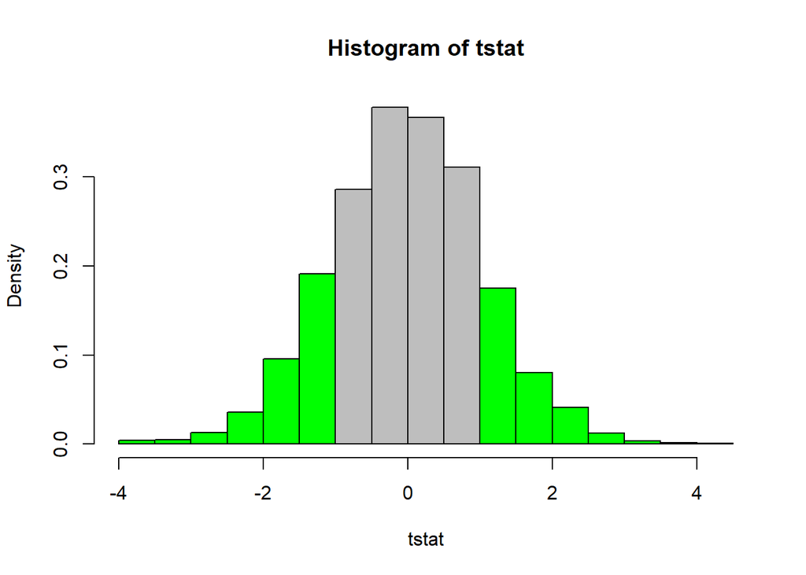

```
## $pvalue
## [1] 0.2436667
```

```r
set.seed(30);x=rnorm(20,mean=15,sd=4)
set.seed(40);y=rnorm(20,mean=15,sd=3)
mypackage::boot2pval(x1=x,x2=y)
```